# Analysis

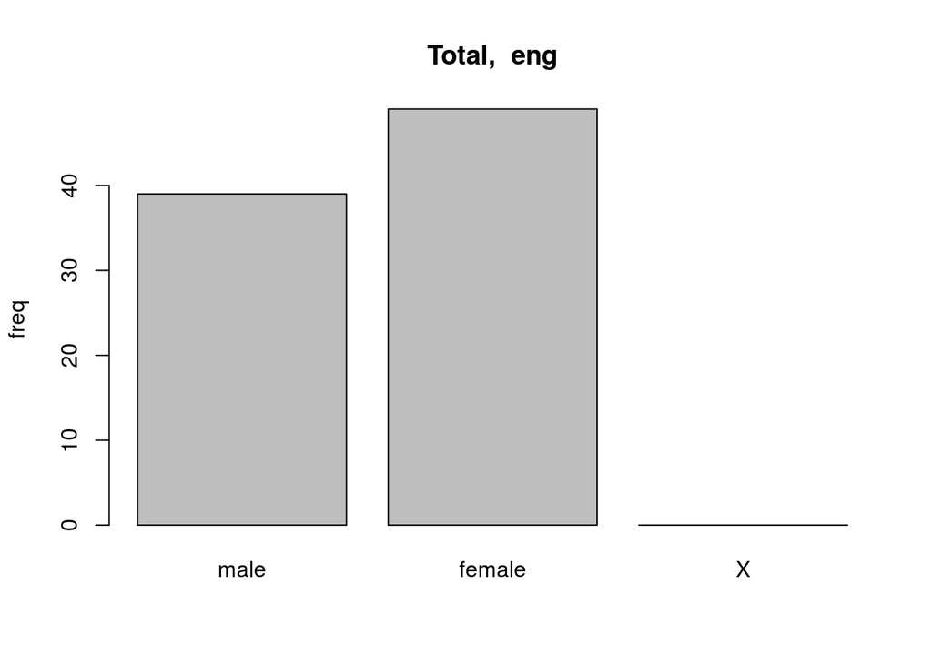

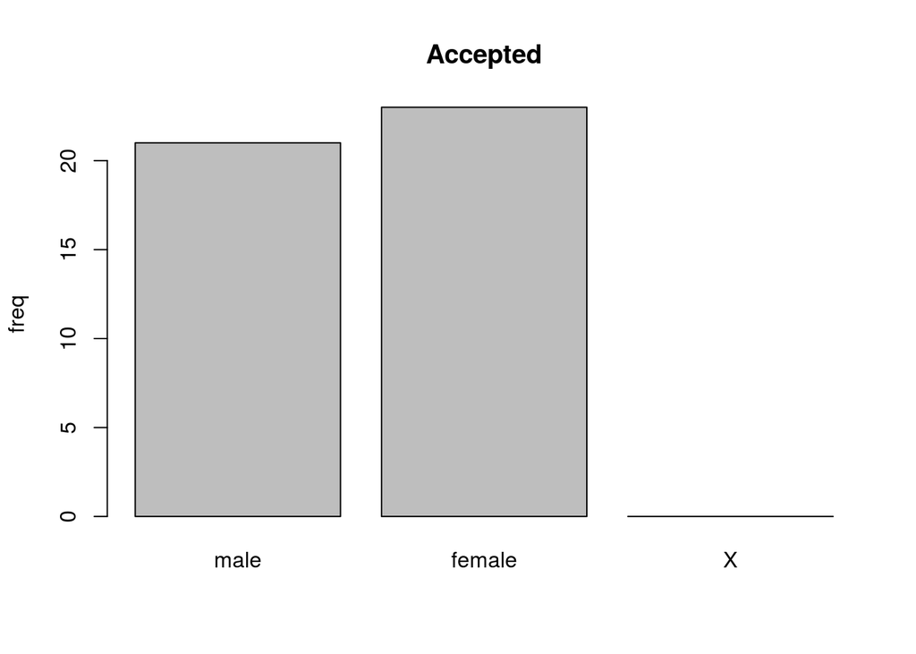

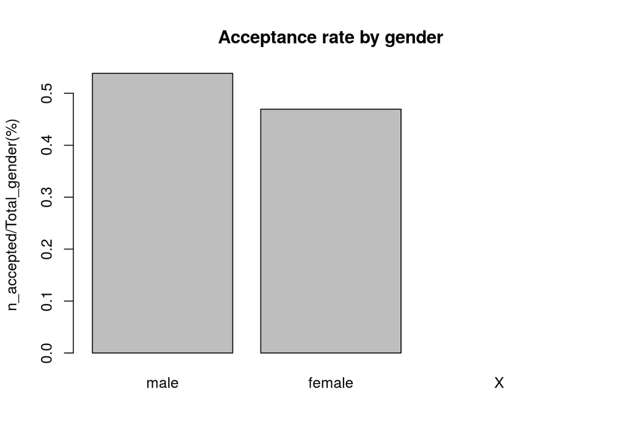

```
## [1] "eng  panel"
##         male     female both
## 1 39.0000000 49.0000000 88.0
## 2 21.0000000 23.0000000 44.0
## 3  0.5384615  0.4693878  0.5
```

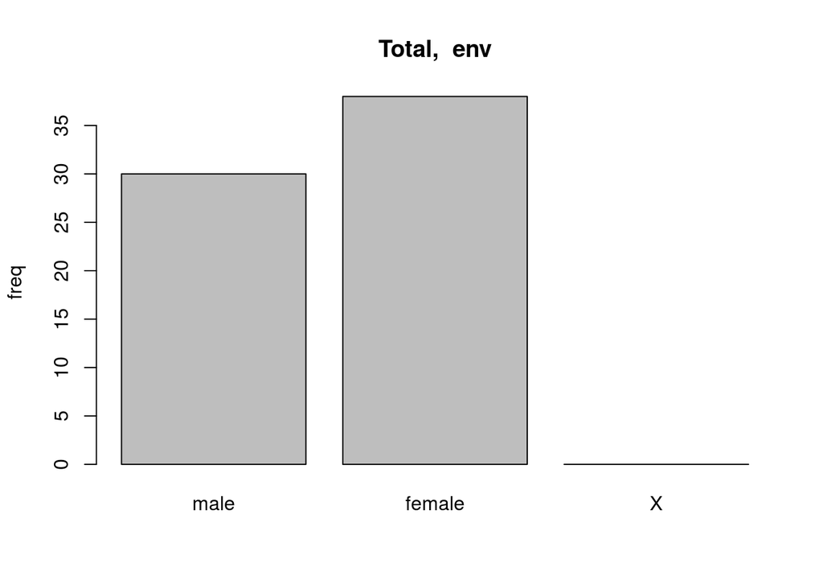

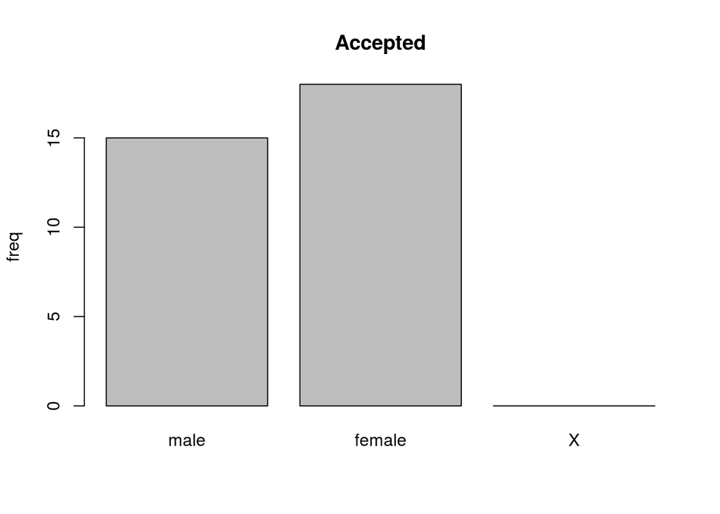

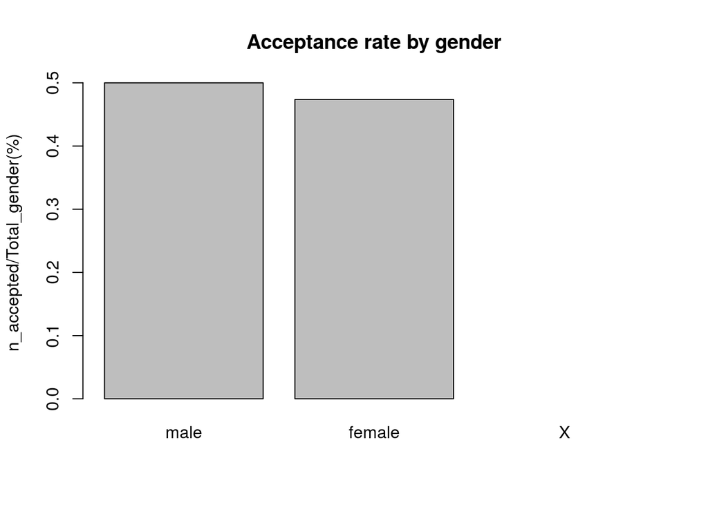

```
## [1] "env  panel"
##   male     female       both
## 1 30.0 38.0000000 68.0000000
## 2 15.0 18.0000000 33.0000000
## 3  0.5  0.4736842  0.4852941
```

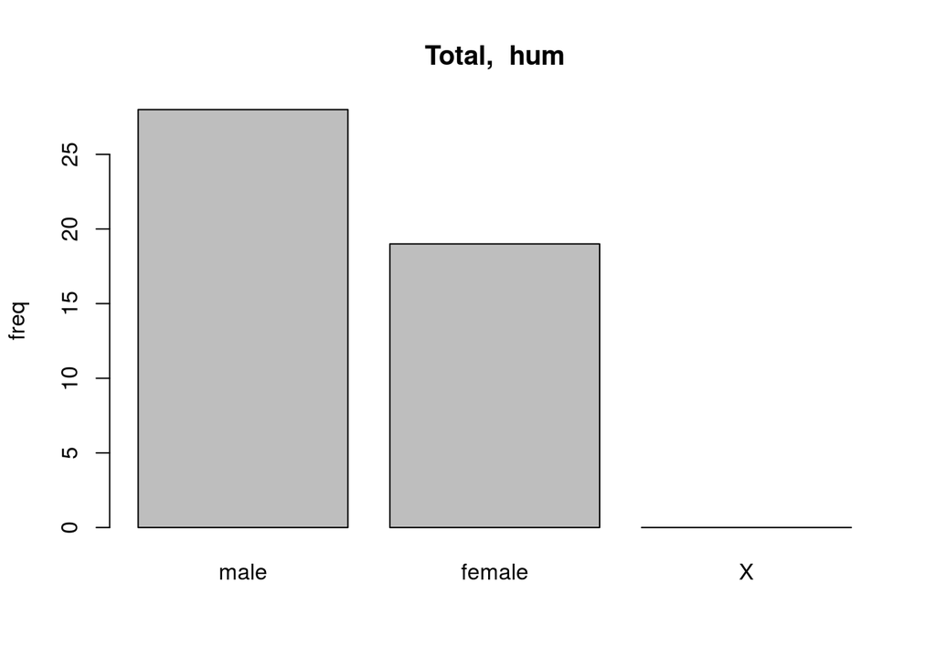

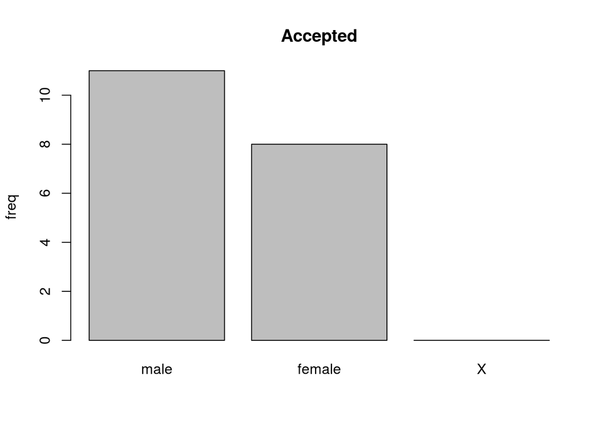

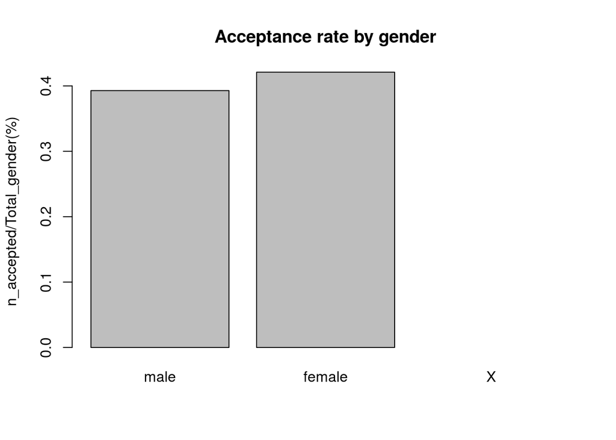

```
## [1] "hum  panel"
##         male     female       both
## 1 28.0000000 19.0000000 47.0000000
## 2 11.0000000  8.0000000 19.0000000
## 3  0.3928571  0.4210526  0.4042553
```

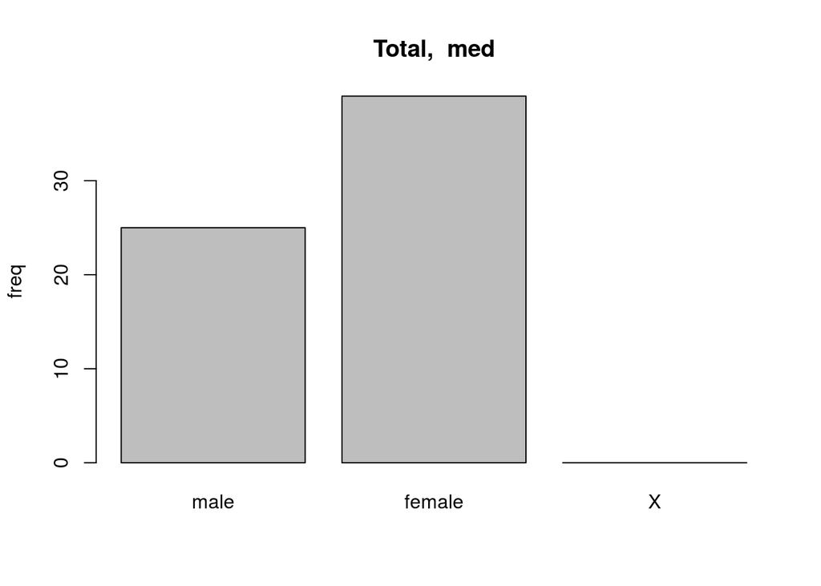

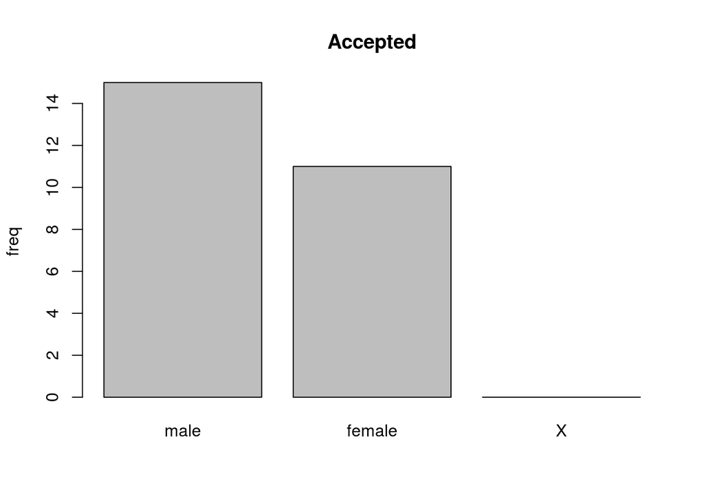

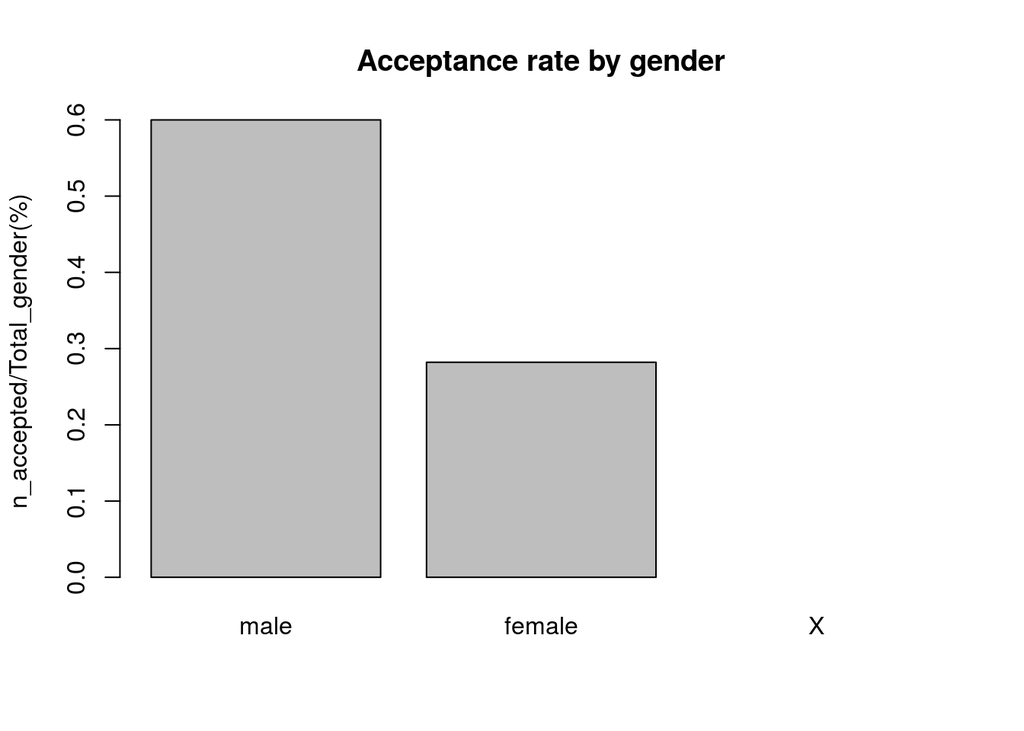

```
## [1] "med  panel"
##   male     female     both
## 1 25.0 39.0000000 64.00000
## 2 15.0 11.0000000 26.00000
## 3  0.6  0.2820513  0.40625
```

[9 more figures not shown]

```
## [1] "soc  panel"
##         male     female       both
## 1 29.0000000 29.0000000 58.0000000
## 2 11.0000000 11.0000000 22.0000000
## 3  0.3793103  0.3793103  0.3793103
```

```r
  # Acceptance rates by gender for stage 2 for each panel
  panel_names <- levels(data2014$Panel)[levels(data2014$Panel)!="empty"]
  i<-0
  for (panel_name in panel_names) {
    i<-i+1
    #plots_list[[i]]<-
    data_temp<-data2014[data2014$gender!="X" & !is.na(data2014$WGrade6)  & data2014$Panel==panel_name,c("WGrade6","gender","Status6")]
    barplot(c(sum(data_temp$gender=="male"),sum(data_temp$gender=="female"),sum(data_temp$gender=="X")),names.arg= c("male","female","X"),main = paste("Total, ",panel_name),ylab = "freq")
    barplot(c(sum(data_temp$gender=="male" & data_temp$Status6=="Yes"),sum(data_temp$gender=="female" & data_temp$Status6=="Yes"),sum(data_temp$gender=="X" & data_temp$Status6=="Yes")),names.arg = c("male","female","X"),main = "Accepted",ylab = "freq")
     barplot(c(sum(data_temp$gender=="male" & data_temp$Status6=="Yes")/sum(data_temp$gender=="male"),sum(data_temp$gender=="female" & data_temp$Status6=="Yes")/sum(data_temp$gender=="female"),sum(data_temp$gender=="X" & data_temp$Status6=="Yes")/sum(data_temp$gender=="X")),names.arg  = c("male","female","X"),main = "Acceptance rate by gender", ylab = "n_accepted/Total_gender(%)")
     # Also provide the numbers
     df_temp <-data.frame(c(sum(data_temp$gender=="male"),sum(data_temp$gender=="male" & data_temp$Status6=="Yes"),sum(data_temp$gender=="male" & data_temp$Status6=="Yes")/sum(data_temp$gender=="male")),c(sum(data_temp$gender=="female"),sum(data_temp$gender=="female" & data_temp$Status6=="Yes"),sum(data_temp$gender=="female" & data_temp$Status6=="Yes")/sum(data_temp$gender=="female")),c(sum(data_temp$gender!="X"),sum(data_temp$gender!="X" & data_temp$Status6=="Yes"),sum(data_temp$gender!="X" & data_temp$Status6=="Yes")/sum(data_temp$gender!="X")))
     colnames(df_temp)<-c("male","female","both")
     show(paste(panel_name," panel"))
     show(df_temp)
  }
```

We note that in some panels the differences are small. To quantify if there is indeed gender discrimination in each panel we should design a test that takes into account the expected spread around teh average acceptance rate assuming “male” and “female” are sampled from the same distribution.

Going back to the overall distribution of Grade2 summed over all panels, we can try to estimate whether a simpson type paradox is expected based on the “male/female” ratios for each panel that we have for stage2. Furthermore we have some more pieces of data in the FCT Stats report that I have in the references. We know the number of evaluated applications for the following panel aggregations (note that I have cross checked the correctness of these identifications with the total number of accepted candidates): * “med”

```r
  ncandidates2014med <- 173
```

- “sci” + “eng”

```r
  ncandidates2014scieng<- 472
```

- “nat” + “env”

```r
  ncandidates2014natenv<- 439
```

- “soc” + “hum”

```r
  ncandidates2014sochum<- 307
```

Focusing first on the “med” panel, we know that in stage2 the number of remaining female candidates is 39 and of male candidates is 25. The information that we have and that is missing is:

- Total “female-med” stage1: $173x$ ???
- Total “male-med” stage1: $173(1-x)$???
- Total “female-med” stage2: 39
- Total “male-med” stage2: 25
- Distribution of Grade2 for this panel: No ???

**Host acceptance rates**

To analyse this we should also split by panel. Furthermore, it will be convenient to define an ID for each host. I will ID in ascending order of number of applications (or alphabetical for ties). FIX CODE NEXT!!!!!!!!!!!!!!!!!

```r
  hostID2014<-sort(table(data2014$Host))
  hostID2014names <- row.names(hostID2014)
  data2014$HostID <- rep(NA,dim(data2014)[1])
  for (i in 1:length(hostID2014names)) {
    subframe <- data2014[data2014$Host == hostID2014names[i],]$Ref
    for(candidate in subframe){
      data2014[data2014$Ref == candidate,"HostID"]<-hostID2014[i][[1]]
    }
  }
```

### 2.2.3 IF2015

In this call we have much more data.

```r
  head(data2015)
```

```
##             Ref                                     Name
## 1 IF/00001/2015                 Jose Manuel Herrera Vega
## 2 IF/00005/2015                  ENRIQUE CERRILLO CUENCA
## 3 IF/00006/2015          Romana Lopes Almeida dos Santos
## 4 IF/00007/2015 Hugo Miguel Baptista Carreira dos Santos
## 5 IF/00008/2015          Ana Mafalda Vaz Martins Pereira
## 6 IF/00009/2015                     Enrique García Muñoz
##                                                                                      Host
## 1                                                              Universidade de Évora (UE)
## 2 Centro de História de Arte e Investigação Artística da Universidade de Évora (CHAIA/UE)
## 3                                 Faculdade de Ciências da Universidade de Lisboa (FC/UL)
## 4                                   Unidade de Ciências Biomoleculares Aplicadas (UCIBIO)
## 5                Unidade de Química Orgânica, Produtos Naturais e Agroalimentares (DQ/UA)
## 6   Centro de Investigação em Biodiversidade de Recursos Genéticos (CIBIO/ICETA-Porto/UP)
##   Panel Grade1 Rank1 Status1 Grade2 Rank2 Status2 Grade3 WGrade3 CVGrade3
## 1   nat    7.0   452     Yes    7.0   455     Yes      8     7.6        8
## 2 empty    6.5   694      No    6.5   700      No     NA      NA       NA
## 3   nat    7.5   247     Yes    7.5   248     Yes      8     7.9        7
## 4   sci    8.5    13     Yes    8.5    13     Yes      8     8.5        9
## 5 empty    6.0   975      No    6.0   984      No     NA      NA       NA
## 6 empty    3.5  1350      No    3.5  1356      No     NA      NA       NA
##   ResearchGrade3 CareerPlanGrade3 Rank3 PanelRank3 Status3
## 1              7                8   235         20     Yes
## 2             NA               NA    NA         NA   empty
## 3              9                8   233         18     Yes
## 4              8                8    72          8     Yes
## 5             NA               NA    NA         NA   empty
## 6             NA               NA    NA         NA   empty
```

The other thing we can look at is gender information. Let us create a column for this field and let us provisionally fill it using the gender resolution list that we already produced

```r
  data2015$gender <- rep("X",dim(data2015)[1])
  head(data2015)
```

```
##             Ref                                     Name
## 1 IF/00001/2015                 Jose Manuel Herrera Vega
## 2 IF/00005/2015                  ENRIQUE CERRILLO CUENCA
## 3 IF/00006/2015          Romana Lopes Almeida dos Santos
## 4 IF/00007/2015 Hugo Miguel Baptista Carreira dos Santos
## 5 IF/00008/2015          Ana Mafalda Vaz Martins Pereira
## 6 IF/00009/2015                     Enrique García Muñoz
##                                                                                      Host
## 1                                                              Universidade de Évora (UE)
## 2 Centro de História de Arte e Investigação Artística da Universidade de Évora (CHAIA/UE)
## 3                                 Faculdade de Ciências da Universidade de Lisboa (FC/UL)
## 4                                   Unidade de Ciências Biomoleculares Aplicadas (UCIBIO)
## 5                Unidade de Química Orgânica, Produtos Naturais e Agroalimentares (DQ/UA)
## 6   Centro de Investigação em Biodiversidade de Recursos Genéticos (CIBIO/ICETA-Porto/UP)
##   Panel Grade1 Rank1 Status1 Grade2 Rank2 Status2 Grade3 WGrade3 CVGrade3
## 1   nat    7.0   452     Yes    7.0   455     Yes      8     7.6        8
## 2 empty    6.5   694      No    6.5   700      No     NA      NA       NA
## 3   nat    7.5   247     Yes    7.5   248     Yes      8     7.9        7
## 4   sci    8.5    13     Yes    8.5    13     Yes      8     8.5        9
## 5 empty    6.0   975      No    6.0   984      No     NA      NA       NA
## 6 empty    3.5  1350      No    3.5  1356      No     NA      NA       NA
##   ResearchGrade3 CareerPlanGrade3 Rank3 PanelRank3 Status3 gender
## 1              7                8   235         20     Yes      X
## 2             NA               NA    NA         NA   empty      X
## 3              9                8   233         18     Yes      X
## 4              8                8    72          8     Yes      X
## 5             NA               NA    NA         NA   empty      X
## 6             NA               NA    NA         NA   empty      X
```

Now let us apply the gender list that we have

```r
  for (i in 1:dim(data2015)[1]) {
    full_name <- as.character(data2015$Name[i])
    first_name <- as.character(strsplit(full_name,split = " ")[[1]][1])
    list_pos <- first_name==gender_results_final$Name
    if(sum(list_pos)==1)
      data2015[i,"gender"]<-gender_results_final[list_pos,"gender"]
  }
  head(data2015[,c("Name","gender")])
```

```
##                                       Name gender
## 1                 Jose Manuel Herrera Vega   male
## 2                  ENRIQUE CERRILLO CUENCA   male
## 3          Romana Lopes Almeida dos Santos female
## 4 Hugo Miguel Baptista Carreira dos Santos   male
## 5          Ana Mafalda Vaz Martins Pereira female
## 6                     Enrique García Muñoz   male
```

```r
  head(data2015[data2015$gender=="X",c("Name","gender")])
```

```
##                               Name gender
## 31                         Ying Ma      X
## 56                    Andrea Zille      X
## 101                       Yang Tao      X
## 104                  Phan Thanh An      X
## 117 Mihaela-Adriana Moreno Perdomo      X
## 148           Lia-Tânia Rosa Dinis      X
```

```r
  dim(data2015[data2015$gender=="X",c("Name","gender")])
```

```
## [1] 70  2
```

Now I check the names that are undetermined by looking online for personal webpages. In particular, if I find a photo and it is in a national institute I assume I am getting the right person:

```r
  data2015[data2015$gender=="X",c("Name","gender")]
```

```
##                                        Name gender
## 31                                  Ying Ma      X
## 56                             Andrea Zille      X
## 101                                Yang Tao      X
## 104                           Phan Thanh An      X
## 117          Mihaela-Adriana Moreno Perdomo      X
## 148                    Lia-Tânia Rosa Dinis      X
## 184                         Lozza Valentina      X
## 207                              Daowen Qiu      X
## 232                 VUILLERMOT Pierre-André      X
## 235                       Koigoora Srikanth      X
## 265   Tsyhanou Dzmitry Leonidovich Tsyhanou      X
## 266                         Coro Echeverria      X
## 274                    Sodikdjon A. Kodirov      X
## 318                   Czinner, Viktor Gábor      X
```

[output cut: 56 more lines]

```r
  data2015[31,"gender"]<-"female"
  data2015[56,"gender"]<-"male"
  data2015[101,"gender"]<-"male"
  data2015[104,"gender"]<-"male"
  data2015[117,"gender"]<-"female"
  data2015[148,"gender"]<-"female"
  data2015[184,"gender"]<-"female"
  data2015[207,"gender"]<-"male"
  data2015[232,"gender"]<-"male"
  data2015[235,"gender"]<-"male"
  data2015[266,"gender"]<-"female"
  data2015[318,"gender"]<-"male"
  data2015[330,"gender"]<-"female"
  data2015[331,"gender"]<-"male"
  data2015[341,"gender"]<-"male"
  data2015[361,"gender"]<-"female"
  data2015[362,"gender"]<-"male"
  data2015[363,"gender"]<-"male"
  data2015[399,"gender"]<-"male"
  data2015[418,"gender"]<-"male"
  data2015[451,"gender"]<-"male"
  data2015[452,"gender"]<-"female"
  data2015[480,"gender"]<-"male"
  data2015[491,"gender"]<-"male"
  data2015[493,"gender"]<-"male"
  data2015[510,"gender"]<-"male"
  data2015[520,"gender"]<-"female"
  data2015[545,"gender"]<-"male"
  data2015[552,"gender"]<-"male"
  data2015[602,"gender"]<-"female"
  data2015[686,"gender"]<-"female"
  data2015[737,"gender"]<-"male"
  data2015[743,"gender"]<-"male"
  data2015[817,"gender"]<-"male"
  data2015[868,"gender"]<-"female"
  data2015[892,"gender"]<-"male"
  data2015[902,"gender"]<-"female"
  data2015[931,"gender"]<-"male"
  data2015[935,"gender"]<-"male"
  data2015[943,"gender"]<-"male"
  data2015[1024,"gender"]<-"male"
  data2015[1044,"gender"]<-"male"
  data2015[1048,"gender"]<-"male"
  data2015[1063,"gender"]<-"male"
  data2015[1085,"gender"]<-"male"
  data2015[1112,"gender"]<-"male"
  data2015[1132,"gender"]<-"female"
  data2015[1142,"gender"]<-"female"
  data2015[1159,"gender"]<-"male"
  data2015[1174,"gender"]<-"female"
  data2015[1176,"gender"]<-"male"
  data2015[1242,"gender"]<-"male"
  data2015[1265,"gender"]<-"male"
  data2015[1276,"gender"]<-"male"
  data2015[1282,"gender"]<-"female"
  data2015[1293,"gender"]<-"male"
  data2015[1330,"gender"]<-"male"
  data2015[1338,"gender"]<-"female"
  data2015[1340,"gender"]<-"male"
  data2015[1365,"gender"]<-"female"
```

The percentage of candidates with undetermined gender is small:

```r
  sum(data2015$gender=="X")*100./dim(data2015)[1]
```

```
## [1] 0.7315289
```

So we remove these candidates from any gender analysis. Note also that if there are missidentified genders either due to mistakes or ambiguities, we do not expect it to bias the analysis since it should be roughly equally likely that a mistake is done in either direction and also it should be a small number of cases.

**Gender distributions**

1. Acceptance rates

```r
  # Proportion of male vs female candidates
  data.frame(c(sum(data2015$gender=="male"),sum(data2015$gender=="female"),sum(data2015$gender=="X")),row.names = c("male","female","X"),fix.empty.names  = FALSE)
```

```
##
## male   637
## female 720
## X       10
```

```r
  # Absolute acceptance by gender
   data.frame(c(sum(data2015$gender=="male" & data2015$Status3=="Yes"),sum(data2015$gender=="female" & data2015$Status3=="Yes"),sum(data2015$gender=="X" & data2015$Status3=="Yes")),row.names = c("male","female","X"),fix.empty.names  = FALSE)
```

```
##
## male   103
## female  97
## X        0
```

```r
  # Acceptance rate by gender
   data.frame(c(sum(data2015$gender=="male" & data2015$Status3=="Yes")/sum(data2015$gender=="male"),sum(data2015$gender=="female" & data2015$Status3=="Yes")/sum(data2015$gender=="female"),sum(data2015$gender=="X" & data2015$Status3=="Yes")/sum(data2015$gender=="X")),row.names = c("male","female","X"),fix.empty.names  = FALSE)
```

```
##
## male   0.1616954
## female 0.1347222
## X      0.0000000
```

2. Distribution of Grades

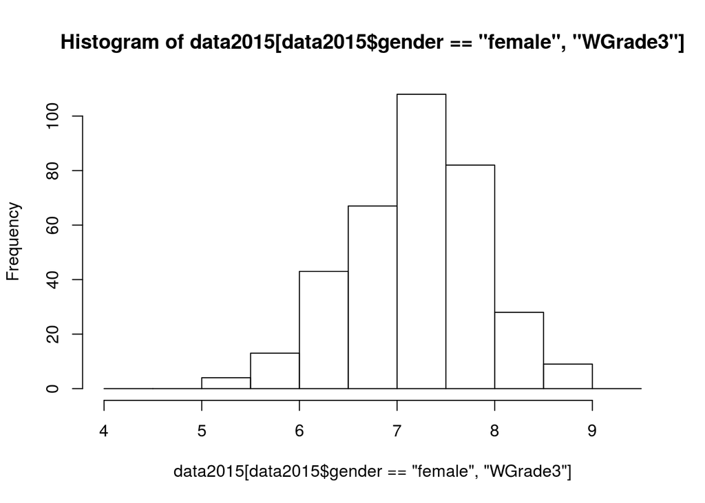

```r
  # distribution of marks per gender
  hist(data2015[data2015$gender=="female","WGrade3"],seq(4,9.5,by = 0.5))
```

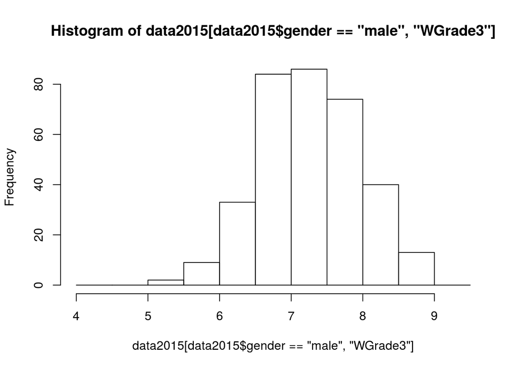

```r
  hist(data2015[data2015$gender=="male","WGrade3"],seq(4,9.5,by = 0.5))
```

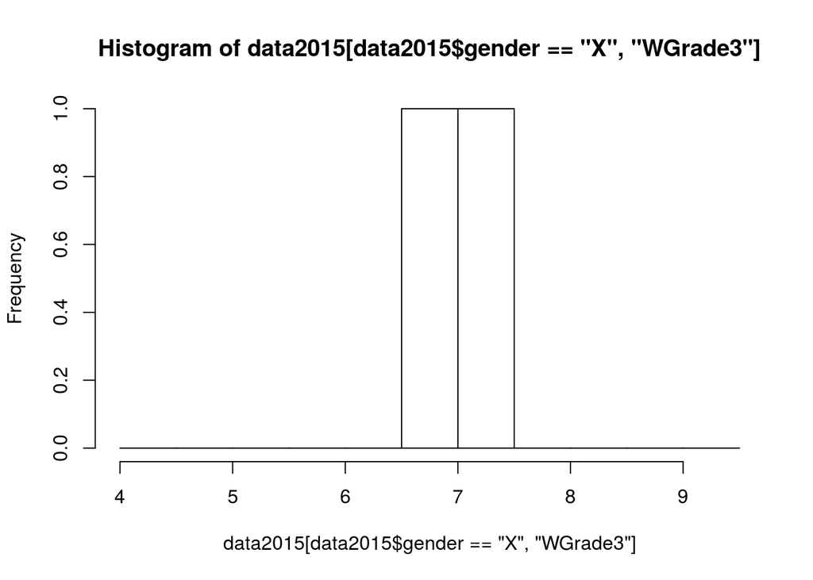

```r
  hist(data2015[data2015$gender=="X","WGrade3"],seq(4,9.5,by = 0.5))
```

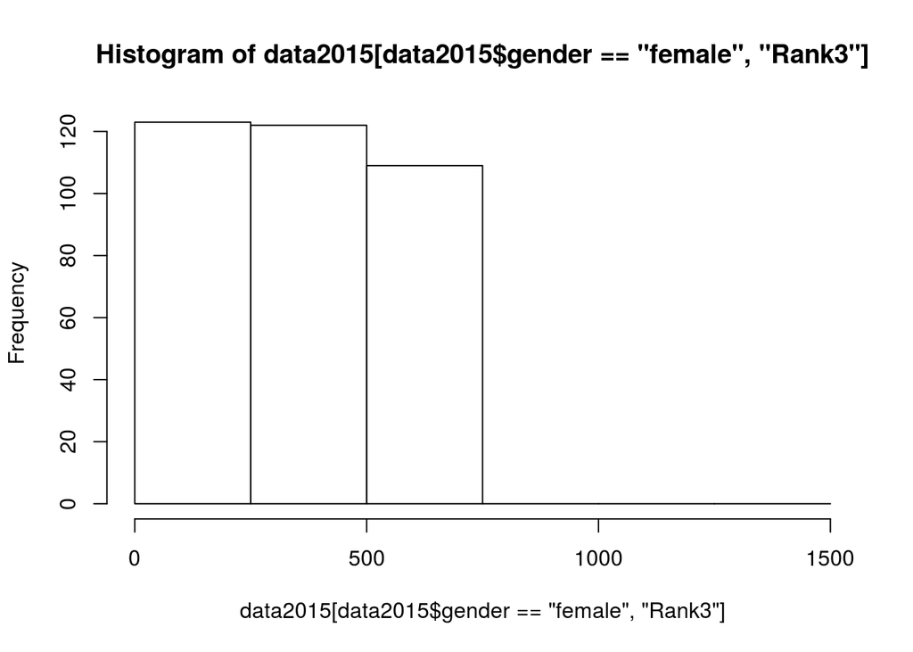

```r
  # distribution of rankings per gender
  hist(data2015[data2015$gender=="female","Rank3"],seq(0,1500,by = 250))
```

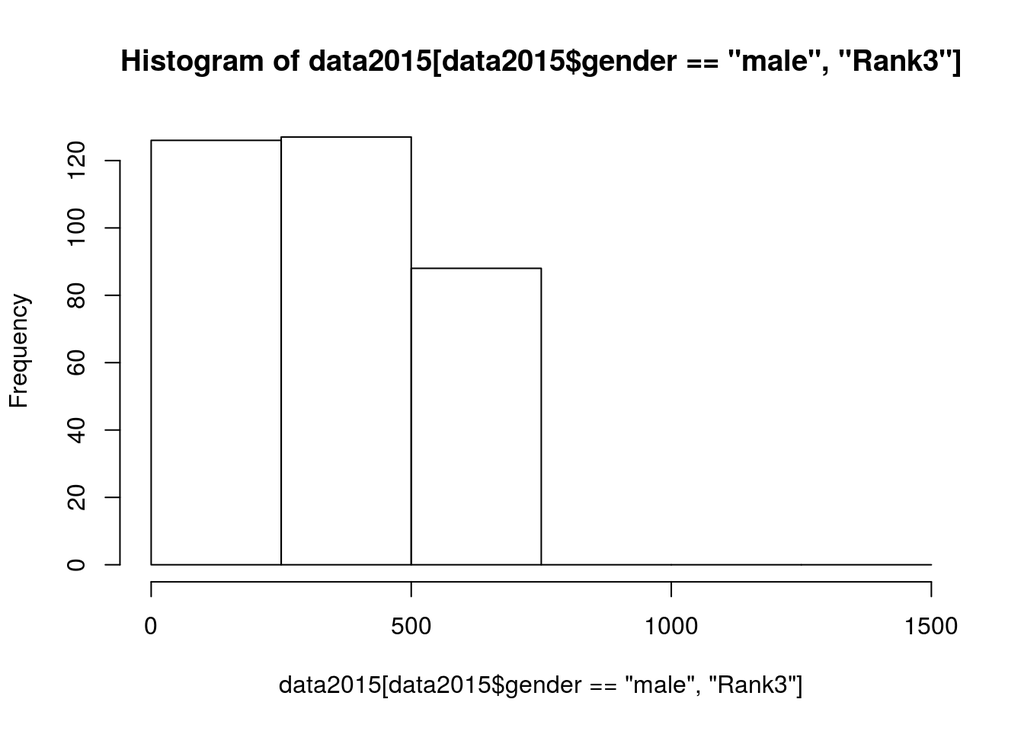

```r
  hist(data2015[data2015$gender=="male","Rank3"], seq(0,1500,by = 250))
```

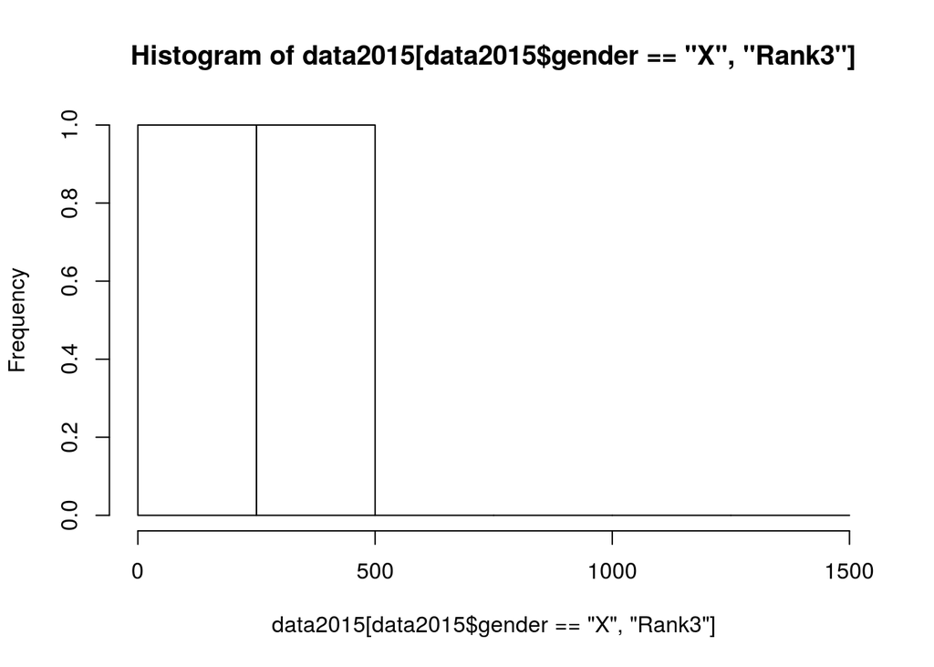

```r
  hist(data2015[data2015$gender=="X","Rank3"], seq(0,1500,by = 250))
```

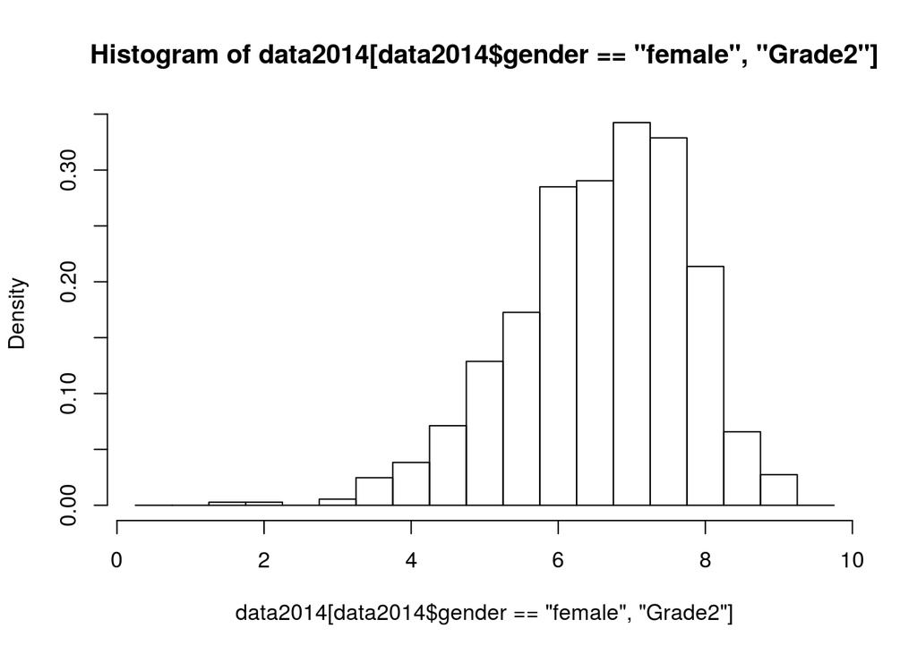

```r
  # Disttributions of grades by gender at the end of stage 1
    # distribution of marks per gender
  hist(data2014[data2014$gender=="female","Grade2"],breaks = seq(0.25,9.75,by = 0.5), freq = FALSE)
```

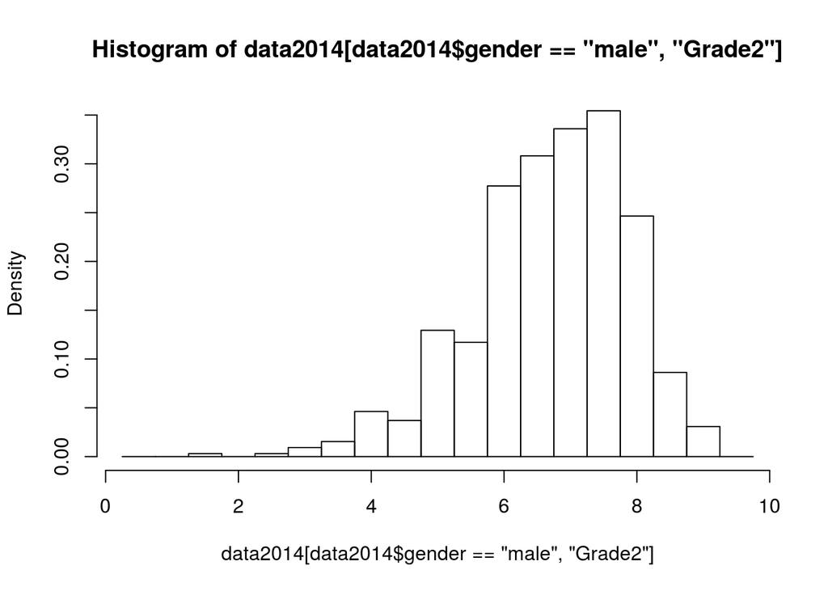

```r
  hist(data2014[data2014$gender=="male","Grade2"],breaks = seq(0.25,9.75,by = 0.5), freq = FALSE)
```

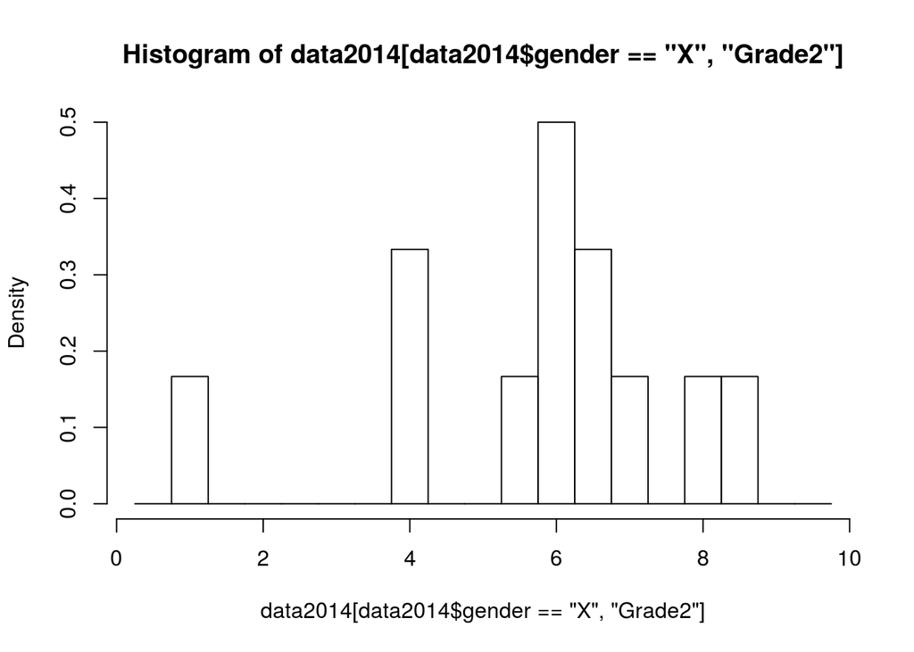

```r
  hist(data2014[data2014$gender=="X","Grade2"],breaks = seq(0.25,9.75,by = 0.5), freq = FALSE)
```

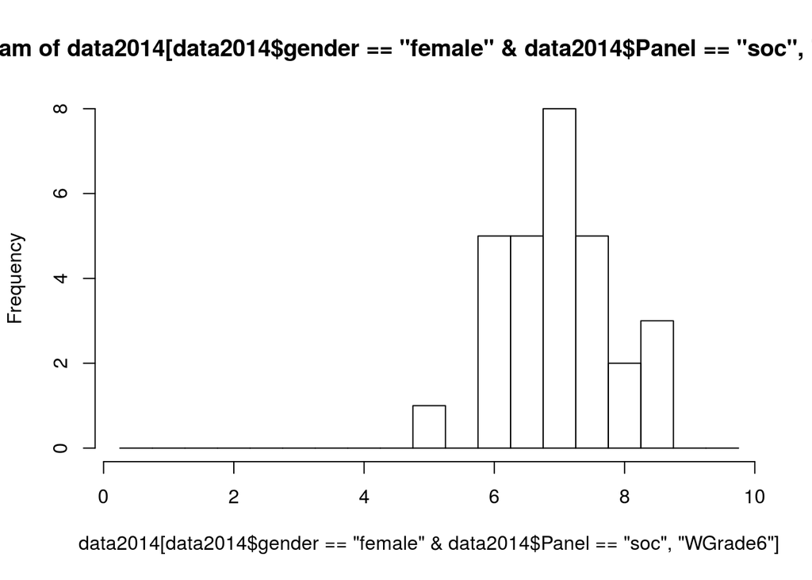

```r
  # Distributions of grades by gender at the end of stage 1 for sciences
    # distribution of marks per gender
  hist(data2014[data2014$gender=="female" & data2014$Panel=="soc","WGrade6"],breaks = seq(0.25,9.75,by = 0.5), freq = TRUE)
```

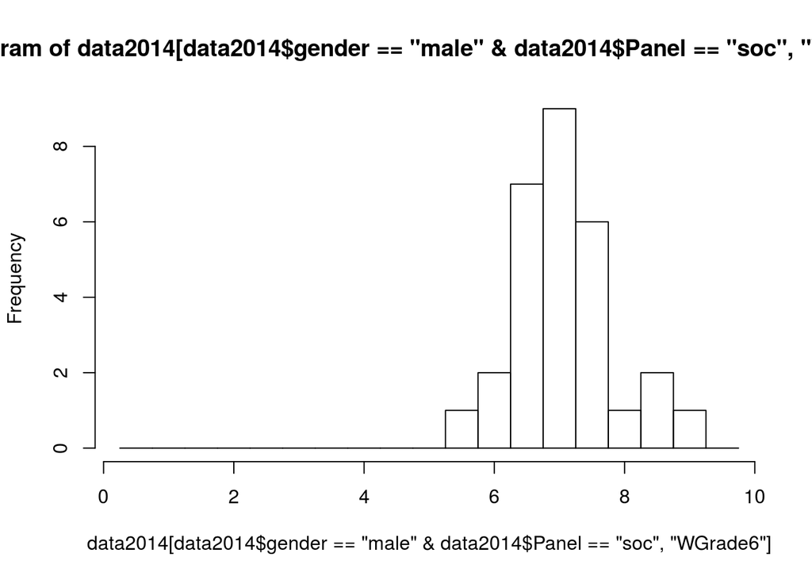

```r
  hist(data2014[data2014$gender=="male" & data2014$Panel=="soc","WGrade6"],breaks = seq(0.25,9.75,by = 0.5), freq = TRUE)
```

### 2.2.4 Accuracy test applied

Now using this sample we will process by hand 300 randomly selected names. We set the seed here to make sure that we always get the same sample when running this notebook again.

```r
  set.seed(1)
  (data2015[data2015$gender !="X",])[sample(as.numeric(dim(data2015)[1]),300),c("Name","gender")]
```

```
##                                                          Name gender
## 365                    Valério Alípio Roberts Machado Ribeiro   male
## 512                                 Raquel Oliveira Cristóvão female
## 786                      Miguel Ângelo Dos Santos Machuqueiro   male
## 1248         Maria Isabel da Fonseca e Castro Moreira Azevedo female
## 277                Patricia Catarina dos Reis Macedo Abrantes female
## 1233                                    Santiago Vilar Varela   male
## 1295                                          Alexey Koshelev   male
## 905                                     Sonia Jerez Rodríguez female
## 859                             Sandra Sofia Costa dos Santos female
## 84                     Ana Paula Bexiga Martins Arguelles Gil female
## 282                                 Irene Isabel Cruz Martins female
## 240                                                Marko Beko   male
## 937                    Filomena Augusta da Silva Antas Parada female
## 524                          Rute Alexandra Borges de Almeida female
```

[output cut: 286 more lines]

For the portuguese names that are 100% obviously gender specific I will not look up for webpages. Also my R command above selected a names in a position that did not exist in the dataframe without X values so the total number of checked cases was actually 299. After looking up one by one I found zero mistakes. So we expect less than 1% mistakes at an estimated 95% confidence level.

# 3 Statistical analysis

**TO DO:**

- Gender bias in panels at stage2 for 2014 and 2015:
  - Apply a t-test (given we do not know the mean and standard deviation of the underlying distribution) to the random variable “Acceptance rate”.
  - Apply a test to the distribution of Grade6 in each panel for “male” and “female” to assess if they are drawn from the same distribution. (Mann-Whitney?)

Examples of tests that I can make:

- In the gender analysis:
  - Test if the distributions of grades in each panel for the male and female populations are drawn from the same distribution (this would be the null H0) for each panel. I need to pay particular attention to panels where the number of male and female applications are the same because in that case I can sum over panels without the risk of running into simpson’s paradox.

# 4 Summary of results

# 5 References

Directly relevant to the FCT investigator program, there is an online file summarising some very basic stats in this webpage https://www.fct.pt/estatisticas/emprego-cientifico/index.phtml.pt. This may be useful to cross-check my analysis. Let us download it

```r
  make_data_file_download("references",".","https://www.fct.pt/estatisticas/emprego-cientifico/docs/Doc_Emprego_Cientifico_PT.pdf","Doc_Emprego_Cientifico_PT.pdf")
```

```
## [1] "references/./Doc_Emprego_Cientifico_PT.pdf"
```